# ggplot2版: 50个matplotlib常用可视化图

pmgh

2025-04-15

ggplot2版: 50个matplotlib常用可视化图

此前看过一篇教程，总结了python matplotlib制作7类50种图的代码。我不习惯这样的画图方式，于是尝试用R ggplot2重画这些图。本文目的是，尽可能实现和原教程中一模一样的图，以此来熟悉ggplot2中的各种调节功能。

注意:

1. 本文只是在尽可能地复现这些图，而并非认可它们清晰、明确，实际上其中一些图画得非常不好。然而，重点在于，通过使用ggplot2以各种特定形式画图，有助于了解ggplot2适合实现哪些功能或不能实现哪些功能，从而进一步了解ggplot2。
2. 本文是在Rstudio中使用Rmd格式写的，所有图像都是在Rmd中的显示效果，相同代码在Rgui、R窗口中或保存时，画图效果可能会有差别，尤其是文字、线条、图例的大小和位置，这需要再次调整相关参数。
3. 画图数据来自github、R或python内部，其中非R内部数据集保留了网址或说明，可自行寻找下载。
4. 画图主要使用ggplot2包，部分功能依赖于ggplot2的辅助包。有些图使用了不同方法，最推荐的是可调参数多的或者是包依赖少的。
5. **文中所有代码均为原创，转载请注明出处。**

原matplotlib教程：

> Top 50 matplotlib Visualizations – The Master Plots (with full python code), https://www.machinelearningplus.com/plots/top-50-matplotlib-visualizations-the-master-plots-python/

# 00. 环境设定

定义文件路径和普遍需要的包。

setwd(“D:/#R/learn_ggplot2”)

```r
library(ggplot2)
library(data.table)
library(magrittr)
knitr::opts_chunk$set(message = FALSE, warning = FALSE)  #全局不返回message
```

# >>> 相关性 —————

相关性下的图用于可视化2个或多个变量之间的关系。也就是说，一个变量相对于另一个变量如何变化。

# 01. 散点图

Scatter plot

用于研究两个变量之间的关系。如果数据中有多个组，则可能需要以不同的颜色可视化每个组。

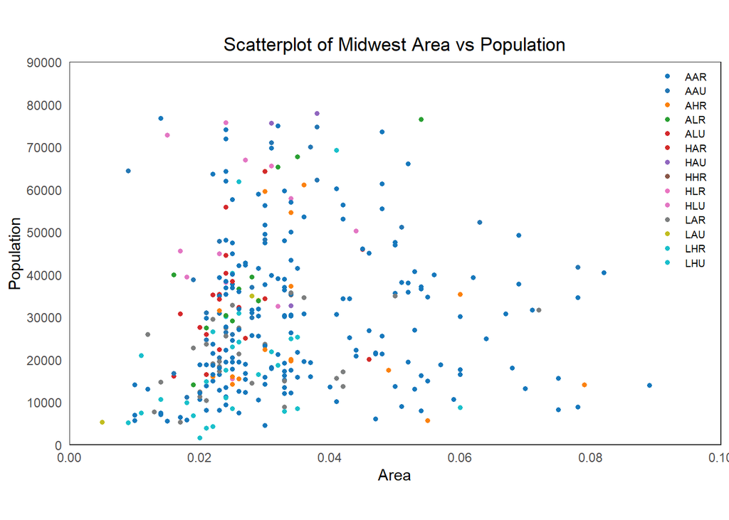

```r
# 数据来自github，与ggplot2::midwest不同
# df <- fread("https://raw.githubusercontent.com/selva86/datasets/master/midwest_filter.csv")
df <- fread("data1_midwest.csv")  #连接在上面，这里已下载到本地保存使用
df_color <- c("#1578bc", "#2477b4", "#fb810b", "#299f32", "#d5282c", "#d32b29",
              "#9066bf", "#885647", "#ea75c1", "#e376c3", "#7c7e7e", "#c1bd1f",
              "#19c0ca", "#18becc")

ggplot(df, aes(x = area, y = poptotal, color = category))+
  geom_point(size = 1.3)+
  scale_x_continuous(breaks = seq(0, 0.1, by = 0.02), limits = c(0, 0.1), expand = c(0,0,0,0))+
  scale_y_continuous(breaks = seq(0, 90000, by = 10000), limits = c(0, 90000), expand = c(0,0))+
  scale_color_manual(values = df_color)+
  labs(x = "Area", y = "Population", color = NULL, title = "Scatterplot of Midwest Area vs Population")+
  theme_bw()+
  theme(aspect.ratio = 1/1.7,
        axis.ticks = element_blank(),
        panel.grid = element_blank(),
        legend.text = element_text(size = 7),
        legend.spacing.x = unit(0, "cm"),
        legend.key.height = unit(0.35, "cm"),
        legend.key.width = unit(0.5, "cm"),
        legend.position = c(0.94, 0.72), #markdown中r图像比例有问题，这项可调，
        legend.background = element_blank(),#这项为了在markdown中好看，除去了背景
        plot.title = element_text(hjust = 0.5))
```

# 02. 气泡图（带包围线）

Bubble plot with Encircling

可以显示边界内的一组点以强调其重要性。

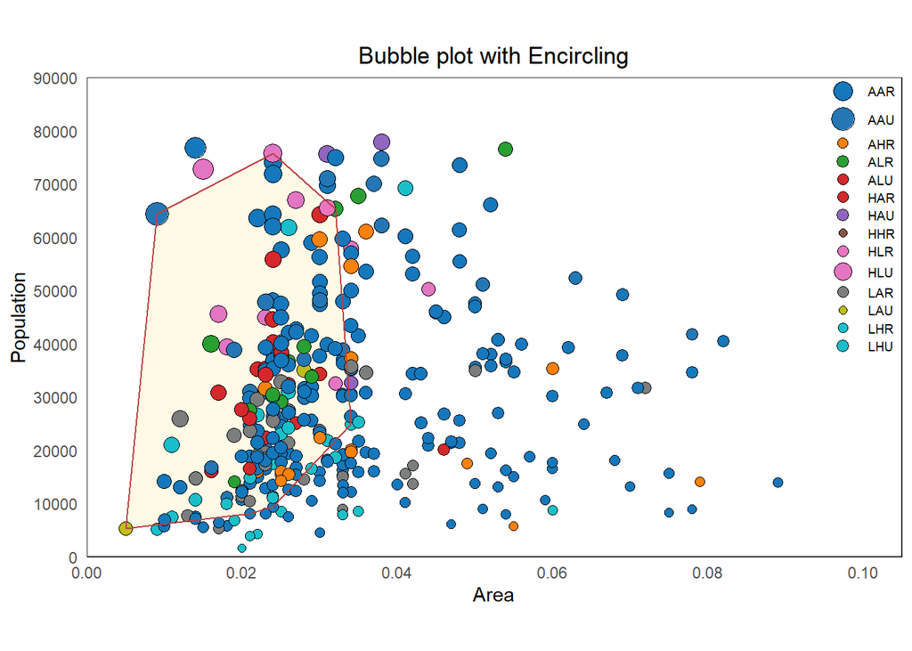

```r
# df <- fread("https://raw.githubusercontent.com/selva86/datasets/master/midwest_filter.csv")
df <- fread("data1_midwest.csv")
# 将category定义为具有顺序的因子类型
df_class <- unique(df$category) %>% .[order(.)]
df[, category:=factor(category, levels = df_class)]
# 定义散点和图标的大小：通过01标准化和乘数、加数调整相对大小
# 不知道matplotlib内部是什么算法，这里就用最大值了
circsize <- df[,max(dot_size), by=category] %>% setorder(category) %>%
  .[, V1 := (V1 - min(.$V1))/(max(.$V1) - min(.$V1))*4+2] %>%
  set_colnames(c("category", "size"))
# 画圈圈住state == "IN"的点
stateIN <- df[state == "IN", c("area", "poptotal")] %>%
  .[c(chull(.), chull(.)[1]),]
# 颜色
df_color <- c("#1578bc", "#2477b4", "#fb810b", "#299f32", "#d5282c", "#d32b29",
              "#9066bf", "#885647", "#ea75c1", "#e376c3", "#7c7e7e", "#c1bd1f",
              "#19c0ca", "#18becc")

# 注意，stroke表示有shape=21的fill的color部分，即外圈的大小
# 为了保证和原图效果一样，这里用polygon图层显示底纹，path图层显示线，实际上polygon也有线图层了，只不过在散点图之下
# 点的大小尺度，和python中有所差别，可能与这里的线性变换有关
# ggalt::geom_encircle也可以画包围线，但是包围线是光滑的，并不是端点连线
ggplot()+
  geom_polygon(data = stateIN, mapping = aes(x = area, y = poptotal, group = 1), fill = "#fffae5", color = "#ba413f", size = 0.4, alpha = 1)+
  geom_point(data = df, mapping = aes(x = area, y = poptotal, fill = category, size = dot_size), color = "black", shape = 21, stroke = 0.3)+
  geom_path(data = stateIN, mapping = aes(x = area, y = poptotal, group = 1), color = "#ba413f", size = 0.4)+  #线图层在点图层上方
  scale_size(range = c(min(circsize$size), max(circsize$size)))+
  scale_fill_manual(values = df_color)+
  scale_x_continuous(breaks = seq(0, 0.1, by = 0.02), limits = c(0, 0.1), expand = c(0,0,0,0.005))+
  scale_y_continuous(breaks = seq(0, 90000, by = 10000), limits = c(0, 90000), expand = c(0,0))+
  guides(fill = guide_legend(override.aes = list(size = circsize$size)), size = FALSE)+
  labs(x = "Area", y = "Population", fill = NULL, size = NULL, title = "Bubble plot with Encircling")+
  theme_bw()+
  theme(aspect.ratio = 1/1.7,
        axis.ticks = element_blank(),
        panel.grid = element_blank(),
        plot.title = element_text(hjust = 0.5),
        legend.text = element_text(size = 7),
        legend.spacing.x = unit(0, "cm"),
        legend.key.height = unit(0.35, "cm"),
        legend.key.width = unit(0.5, "cm"),
        legend.position = c(0.95, 0.71), #markdown中r图像比例有问题，这项可调，
        legend.background = element_blank()) #这项为了在markdown中好看，除去了背景
```

# 03. 散点图（带拟合线）

Scatter plot with linear regression line of best fit

如果想了解两个变量是如何相互变化的，那么可选最佳拟合线。

## 图1，显示不同类别

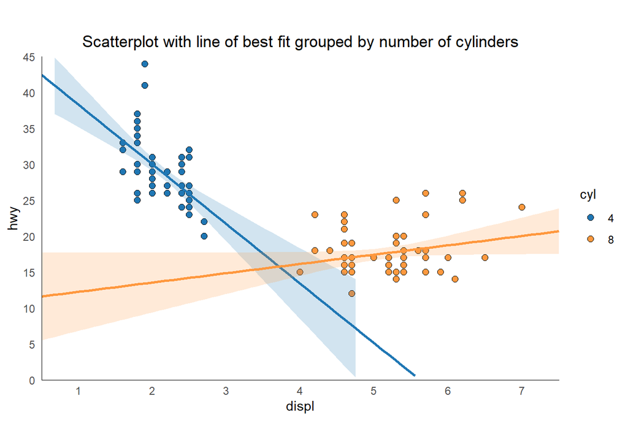

```r
df <- ggplot2::mpg %>% setDT()
df_select <- df[cyl %in% c(4,8),] %>% .[,cyl:=as.factor(cyl)]
# 颜色
cyl_color <- c("#1f77b4", "#ff983e")

# geom_smooth的填充范围，只有数据和全图可选，而且se只会按垂直方向填充，这与python不同
ggplot(df_select, aes(displ, hwy, color = cyl, fill = cyl))+
  geom_point(color = "black", shape = 21, size = 2.3, stroke = 0.2)+
  geom_smooth(formula = "y~ x", method = "lm", fullrange = T, alpha = 0.2, show.legend = F)+
  scale_x_continuous(breaks = 1:7, limits = c(0.5, 7.5), expand = c(0,0,0,0.005))+
  scale_y_continuous(breaks = seq(0, 45, by = 5), limits = c(0, 45), expand = c(0,0))+
  scale_color_manual(values = cyl_color)+
  scale_fill_manual(values = cyl_color)+
  labs(title = "Scatterplot with line of best fit grouped by number of cylinders")+
  theme_bw()+
  theme(aspect.ratio = 1/1.6,     #这里是高1宽1.6，和python的seaborn长宽比是反着的
        axis.line = element_line(linewidth = 0.3),
        axis.ticks = element_blank(),
        panel.grid = element_blank(),
        panel.border = element_blank(),
        plot.title = element_text(hjust = 0.5))
```

## 图2，分组显示类别

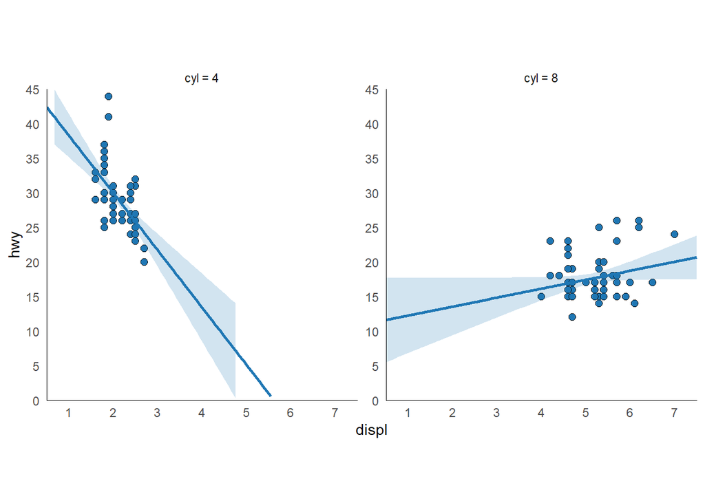

```r
df <- ggplot2::mpg %>% setDT()
df_select <- df[cyl %in% c(4,8),] %>% .[,cyl:=as.factor(cyl)]

# 注意这个图仍和seaborn的有差别，坐标轴上，对方的相当于两个图放一起了，这个没难度，这里就按分面画了一下
ggplot(df_select, aes(displ, hwy))+
  geom_point(color = "black", fill = "#1f77b4", shape = 21, size = 2.3, stroke = 0.2)+
  geom_smooth(formula = "y~ x", method = "lm", fill = "#1f77b4", color = "#1f77b4", fullrange = T, alpha = 0.2, show.legend = F)+
  scale_x_continuous(breaks = 1:7, limits = c(0.5, 7.5), expand = c(0,0,0,0.005))+
  scale_y_continuous(breaks = seq(0, 45, by = 5), limits = c(0, 45), expand = c(0,0))+
  facet_wrap(vars(cyl), scales = "free", labeller = labeller(.default = function(x)  paste0("cyl = ", x)))+
  # facet_wrap(vars(cyl), scales = "free", labeller = function(variable, value) paste0(variable, "=", value))+ #这个方法被新的ggplot弃用了，但是和上一行同样效果
  theme_bw()+
  theme(aspect.ratio = 1/1,
        axis.line = element_line(linewidth = 0.3),
        axis.ticks = element_blank(),
        panel.grid = element_blank(),
        panel.border = element_blank(),
        strip.background = element_rect(fill = F, colour = F),
        plot.title = element_text(hjust = 0.5))
```

# 04. 散点图（带抖动）

Jittering with stripplot

通常，多个数据点具有完全相同的X和Y值，将导致多个点相互绘制并隐藏。为避免这种情况，可稍微抖动点，以便直观地看到它们。

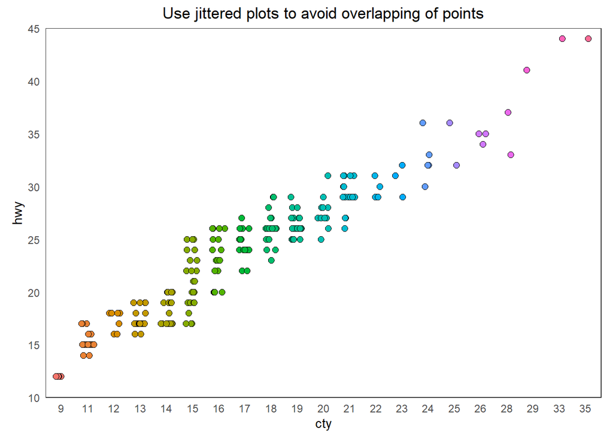

```r
df <- ggplot2::mpg %>% setDT() %>% .[,cty:=factor(cty)]
df_color <- c( "#ff869a", "#9fb428",  "#3fcc84", "#61b5f2","#b19fef","#fa82af")

# 注意这个图的横坐标是因子型，因此并不等宽
# 注意偏离值，python中只能水平偏移，R语言中水平和数值都可设定，并且默认值都不是0，要自定义
# 离散的话，用scale_fill_discrete(df_color)，将自动匹配数量
# 连续的话，用scale_*_gradient/scale_*_gradient2/scale_*_gradientn，分别将中高两种、中高低三种，和任意颜色映射到梯度中，2中的中需要自定义中点值
ggplot(df, aes(cty, hwy, fill = cty))+
  geom_jitter(width = 0.25, height = 0, color = "black", shape = 21, size = 2.3, stroke = 0.2)+
  # scale_x_continuous(breaks = seq(9, 35, by = 1), limits = c(9, 35))+
  scale_y_continuous(breaks = seq(10, 45, by = 5), limits = c(10, 45), expand = c(0,0))+
  scale_fill_discrete(df_color)+
  # scale_fill_gradient2(low = "#ff869a", mid = "#3fcc84", high = "#fa82af", midpoint = 32)+
  # scale_fill_gradientn(colours = colorn)+
  labs(title = "Use jittered plots to avoid overlapping of points")+
  guides(fill = F)+
  theme_bw()+
  theme(aspect.ratio = 1/1.5,    #高宽比1:1.5
        axis.ticks = element_blank(),
        panel.grid = element_blank(),
        plot.title = element_text(hjust = 0.5))
```

# 05. 计数图

Counts Plot

避免点重叠问题的另一种选择是根据该点中有多少个点来增加点的大小。因此，点的大小越大，点周围的集中度就越大。

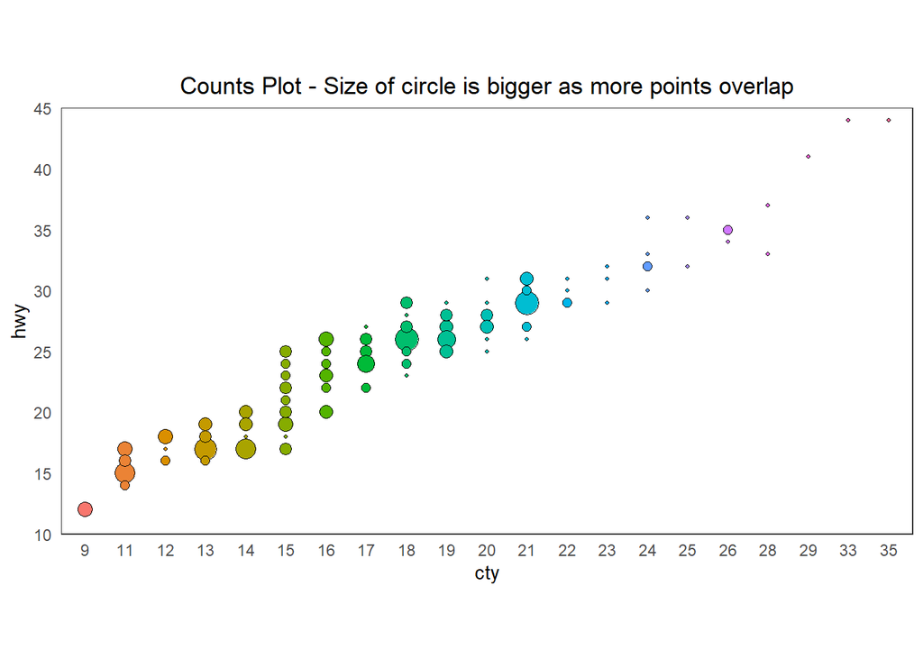

```r
df <- ggplot2::mpg %>%
  setDT() %>%
  .[, length(drv), by=c("cty", "hwy")] %>%
  set_colnames(c("cty", "hwy", "size")) %>%
  .[, cty:=factor(cty)]
df_color <- c( "#ff869a", "#9fb428",  "#3fcc84", "#61b5f2","#b19fef","#fa82af")

# 注意这个图的横坐标是因子型，因此并不等宽
ggplot(df, aes(cty, hwy, size = size, fill = cty))+
  geom_point(color = "black", shape = 21, stroke = 0.2)+
  scale_y_continuous(breaks = seq(10, 45, by = 5), limits = c(10, 45), expand = c(0,0))+
  scale_fill_discrete(df_color)+
  labs(title = "Counts Plot - Size of circle is bigger as more points overlap")+
  guides(fill = F, size = F)+
  theme_bw()+
  theme(aspect.ratio = 1/2,    #高宽比1:2
        axis.ticks = element_blank(),
        panel.grid = element_blank(),
        plot.title = element_text(hjust = 0.5))
```

# 06. 散点图（带边际直方）

Marginal Histogram

边际直方图具有沿X轴和Y轴变量的直方图。这用于可视化X和Y之间的关系以及X和Y的单变量分布。此图经常用于探索性数据分析。

用ggpubr::ggscatterhist也可以，但是是图和边缘图一起画，可调参数较少

这里仅用ggExtra::ggMarginal作图

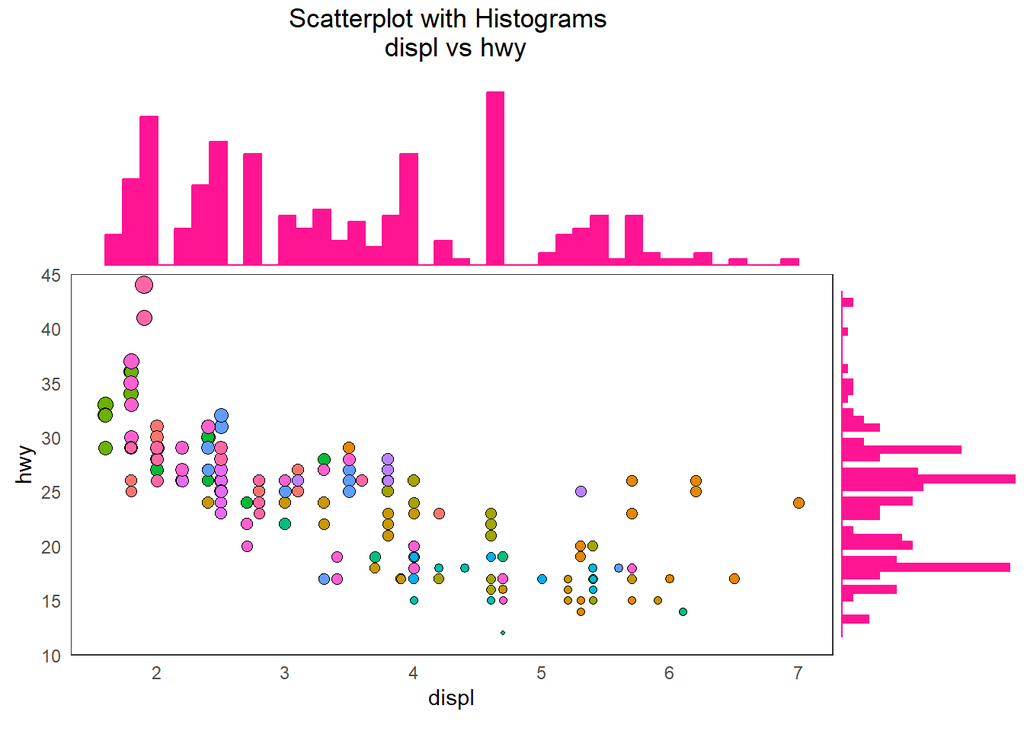

```r
library(ggExtra)
df <- ggplot2::mpg

# 绘制散点图和分布密度，分布图位置不能改只能在右和上
p <- ggplot(df, aes(x = displ, y = hwy, size = cty, fill = manufacturer)) +
  geom_point(color = "black", shape = 21, stroke = 0.2)+
  scale_size(range = c(1,4))+
  scale_y_continuous(breaks = seq(10, 45, by = 5), limits = c(10, 45), expand = c(0,0))+
  guides(size = F, fill = F)+
  labs(title = "Scatterplot with Histograms \n displ vs hwy")+
  theme_bw()+
  theme(aspect.ratio = 1/2,    #高宽比1:2
        axis.ticks = element_blank(),
        panel.grid = element_blank(),
        plot.title = element_text(hjust = 0.5))
ggMarginal(p, type = "histogram",
           fill = "#ff1493", color = "#ff1493", size = 4,
           xparams = list(bins = 41), yparams = list(bins = 48))
```

# 07. 散点图（带边际箱线）

Marginal Boxplot

边际箱线图的作用与边际直方图类似。箱线图有助于精确定位X和Y的中位数、第25个和第75个百分位数。

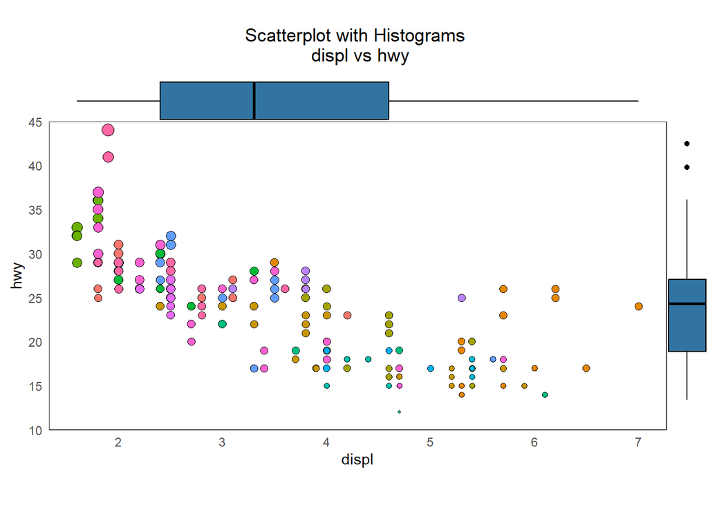

```r
library(ggExtra)
df <- ggplot2::mpg

# 绘制散点图和分布密度，分布图位置不能改只能在右和上
p <- ggplot(df, aes(x = displ, y = hwy, size = cty, fill = manufacturer)) +
  geom_point(color = "black", shape = 21, stroke = 0.2)+
  scale_size(range = c(1,4))+
  scale_y_continuous(breaks = seq(10, 45, by = 5), limits = c(10, 45), expand = c(0,0))+
  guides(size = F, fill = F)+
  labs(title = "Scatterplot with Histograms \n displ vs hwy")+
  theme_bw()+
  theme(aspect.ratio = 1/2,    #高宽比1:2
        axis.ticks = element_blank(),
        panel.grid = element_blank(),
        plot.title = element_text(hjust = 0.5))
# 注意，使用boxplot添加最值横线的方法如下，但是在margin图上没法加这个，所以与pythonseaborn的有差别
# ggplot(mpg, aes(class, hwy)) + stat_boxplot(geom = "errorbar", width = 0.1) + geom_boxplot()

ggMarginal(p, type = "boxplot", size = 15, fill = "#3174a2",
           xparams = list(aes(group = 1)),
           yparams = list(aes(group = 1)))
```

# 08. 相关图

Correllogram

相关图用于直观地查看给定数据（或 2D 数组）中所有可能的数值变量对之间的相关指标。

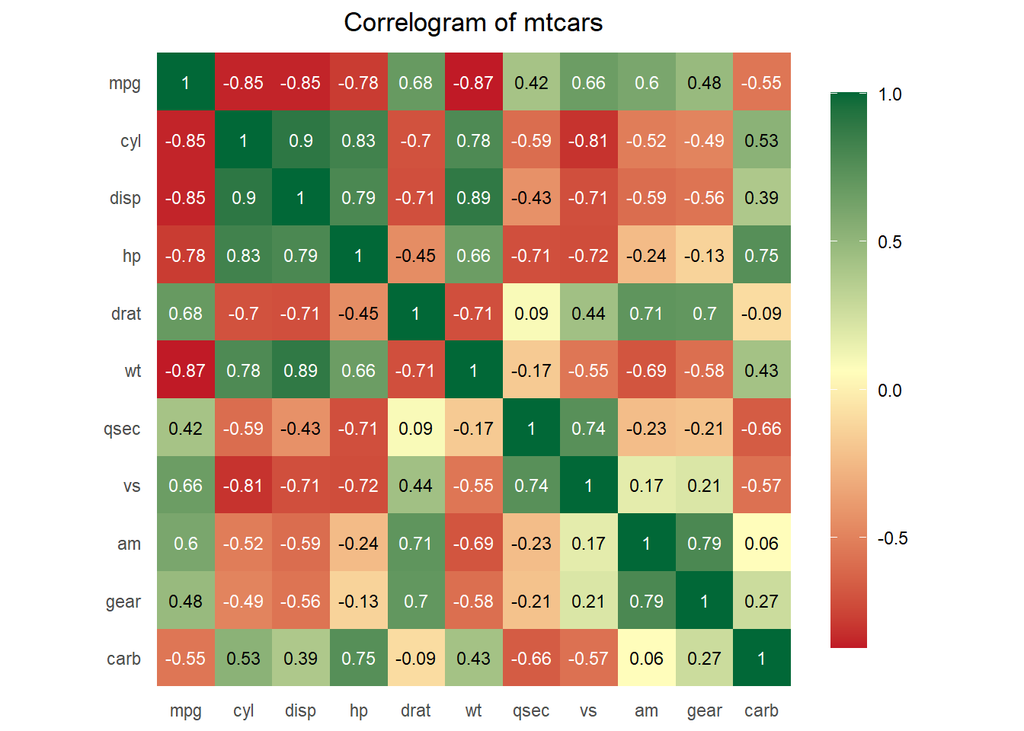

```r
df <- names(datasets::mtcars)
df_color <- c("#c01a26", "#fffebc", "#016837")
text.color <- function(x) if(x > 0.53|x < -0.46) return("w") else return("b")  #数字颜色根据背景颜色调整，更容易看清数字
mtcars.cor <- cor(datasets::mtcars) %>%
  data.table() %>%
  .[,v1:=df] %>%
  melt(id="v1", variable.name="v2", value.name = "cor") %>%
  .[, c("v1", "v2") := list(factor(v1, levels = df), factor(v2, levels = rev(df)))] %>%
  .[, cor:=round(cor, 2)] %>%
  .[, text.col := text.color(cor), by = c("v1","v2")]

# 这个图颜色通过对Python的取色得来，但是颜色没有原图鲜艳
ggplot(mtcars.cor, aes(v1, v2, fill = cor, label = cor))+
  geom_tile()+
  geom_text(mapping = aes(color = text.col), show.legend = F, size = 3)+
  scale_fill_gradientn(colours = df_color)+
  scale_color_manual(values = c("b" = "black", "w" = "white"))+
  guides(fill = guide_colorbar(ticks = FALSE, barheight = 19, barwidth = 1.25))+
  labs(x = NULL, y = NULL, title = "Correlogram of mtcars", fill = NULL)+
  theme_bw()+
  theme(aspect.ratio = 1,
        axis.ticks = element_blank(),
        panel.grid = element_blank(),
        panel.border = element_blank(),
        plot.title = element_text(hjust = 0.5))
```

# 09. 成对图

Pairwise Plot

成对图是探索性分析中最受欢迎的一种，用于了解所有可能的数值变量对之间的关系。它是双变量分析的必备工具。

## 图1，带拟合线

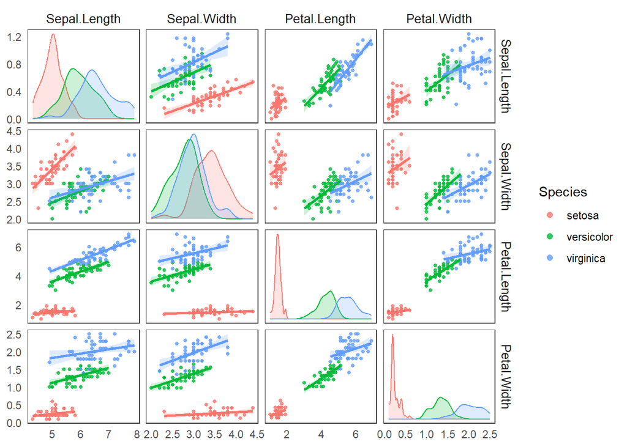

```r
library(GGally)
# 定义散点图
scatter_fn <- function(data, mapping, ...){
  p <- ggplot(data = data, mapping = mapping) +
    geom_point(..., size = 1, alpha = 0.8) +
    geom_smooth(formula = "y ~ x", method = "lm", show.legend = F, alpha = 0.2) +
    guides(fill = guide_legend(override.aes = list(size = 2)))
}
# 定义密度图
diag_density <- function(data, mapping, ...){
  p <- ggplot(data = data, mapping = mapping)+
    geom_density(alpha = 0.2)
}

# 坐标轴和python有差异
ggpairs(datasets::iris, aes(color = Species, fill = Species), columns = 1:4, legend = c(1,2), progress = FALSE,
        upper = list(continuous = scatter_fn),
        lower = list(continuous = scatter_fn),
        diag = list(continuous = diag_density)) +
  theme_bw()+
  theme(axis.ticks = element_blank(),
        panel.grid = element_blank(),
        strip.background = element_rect(fill = F, colour = F),
        strip.text = element_text(size = 10))
```

## 图2，不带拟合线

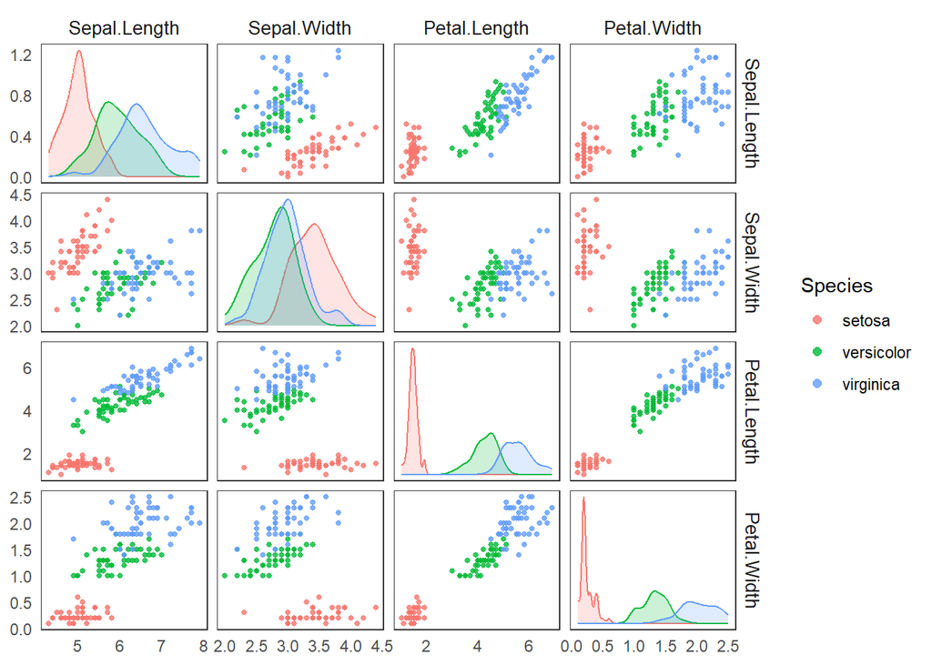

```r
library(GGally)
scatter_fn <- function(data, mapping, ...){
  p <- ggplot(data = data, mapping = mapping) +
    geom_point(..., size = 1, alpha = 0.8) +  # 这里不能定义color="white"，会和ggpairs有冲突
    guides(fill = guide_legend(override.aes = list(size = 2)))
}
diag_density <- function(data, mapping, ...){
  p <- ggplot(data = data, mapping = mapping)+
    geom_density(alpha = 0.2)
}

# 坐标轴和python有差异
ggpairs(datasets::iris, aes(color = Species, fill = Species), columns = 1:4, legend = c(1,2), progress = FALSE,
        upper = list(continuous = scatter_fn),
        lower = list(continuous = scatter_fn),
        diag = list(continuous = diag_density)) +
  theme_bw()+
  theme(axis.ticks = element_blank(),
        panel.grid = element_blank(),
        strip.background = element_rect(fill = F, colour = F),
        strip.text = element_text(size = 10))
```

# >>> 偏差 —————

# 10. 条形图（发散）

Diverging Bars

如果想查看项目如何基于单个指标而变化，并可视化此差异的顺序和数量，则发散条形图是一个很好的工具。它有助于快速区分数据中组的性能，并且非常直观，可以立即传达要点。

geom_linerange、geom_segment和geom_bar都可以实现这类图，前两种方法基本一样

ggplot中，几种画线或线段的函数 1. geom_linerange(), aes是x, ymin, ymax; y线段三个，或x线段三个 2. geom_segment(), aes是x, xend, y, yend，四个都得有 3. geom_vline(), geom_hline(), aes是xintercept或yintercept 4. geom_abline(), aes是slope和intercept

## 方法1，geom_linerange

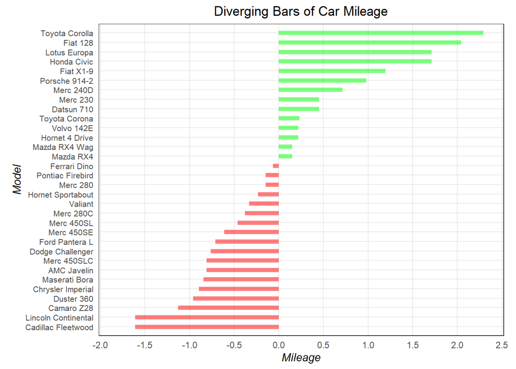

```r
df <- datasets::mtcars %>% data.table() %>% .[,cars:=rownames(mtcars)]
df[, mpg_z := (mpg-mean(mpg))/sd(mpg)]
df[mpg_z > 0, mpg_c := "g"]
df[mpg_z <= 0, mpg_c := "r"]

# 注意Ferrari Dino和原版数值不一样，可能是数据的问题，用本地数据R和Python画出图结果一样
ggplot(df, aes(y = reorder(cars, mpg_z), color = mpg_c))+
  geom_linerange(aes(xmin = 0, xmax = mpg_z), linewidth = 2, alpha = 0.5, show.legend = F)+
  scale_color_manual(values = c("r" = "red", "g" = "green"))+
  scale_x_continuous(limits = c(-2, 2.5), breaks = seq(-2, 2.5, by = 0.5), expand = c(0,0.02))+
  scale_y_discrete(expand = c(0.03, 0.03))+
  labs(x = "Mileage", y = "Model", title = "Diverging Bars of Car Mileage")+
  theme_bw()+
  theme(aspect.ratio = 1/1.3,
        axis.ticks = element_blank(),
        axis.title = element_text(face = "italic"),
        axis.text.y = element_text(size = 8),
        panel.grid.minor = element_blank(),
        plot.title = element_text(hjust = 0.5))
```

## 方法2，geom_segment

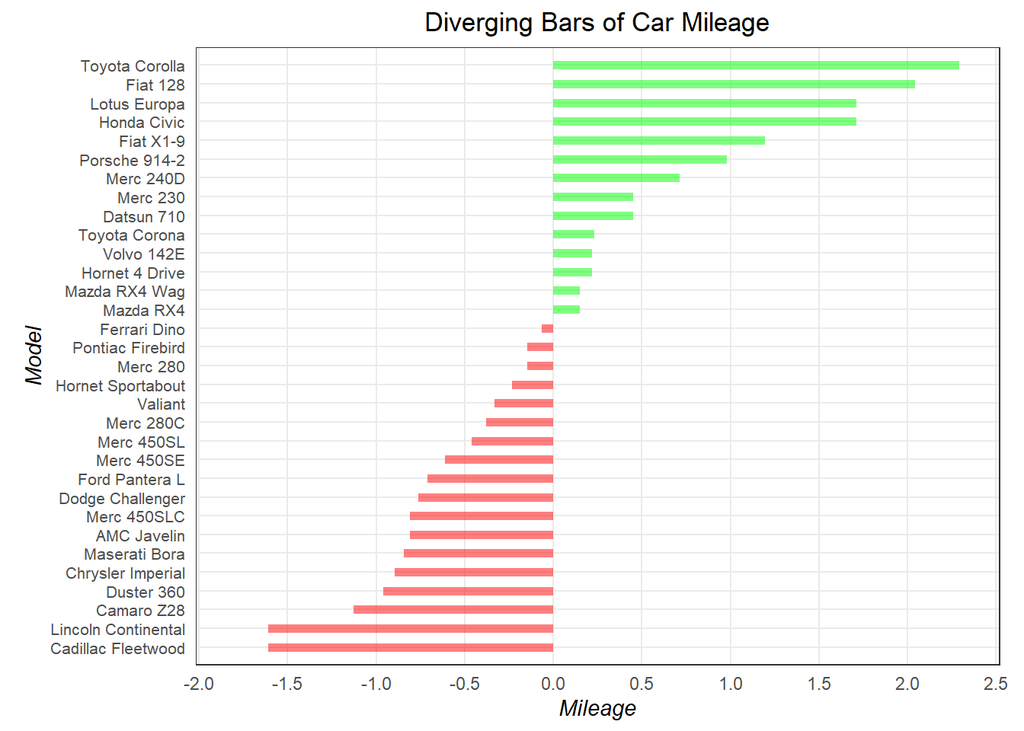

```r
df <- datasets::mtcars %>% data.table() %>% .[,cars:=rownames(mtcars)]
df[, mpg_z := (mpg-mean(mpg))/sd(mpg)]
df[mpg_z > 0, mpg_c := "g"]
df[mpg_z <= 0, mpg_c := "r"]

# 注意Ferrari Dino和原版数值不一样，可能是数据的问题，用本地数据R和Python画出图结果一样
ggplot(df)+
  geom_segment(aes(x = 0, xend = mpg_z, y = reorder(cars, mpg_z), yend = reorder(cars, mpg_z),color = mpg_c), linewidth = 2, alpha = 0.5, show.legend = F)+
  scale_color_manual(values = c("r" = "red", "g" = "green"))+
  scale_x_continuous(limits = c(-2, 2.5), breaks = seq(-2, 2.5, by = 0.5), expand = c(0,0.02))+
  scale_y_discrete(expand = c(0.03, 0.03))+
  labs(x = "Mileage", y = "Model", title = "Diverging Bars of Car Mileage")+
  theme_bw()+
  theme(aspect.ratio = 1/1.3,
        axis.ticks = element_blank(),
        axis.title = element_text(face = "italic"),
        axis.text.y = element_text(size = 8),
        panel.grid.minor = element_blank(),
        plot.title = element_text(hjust = 0.5))
```

## 方法3，geom_bar

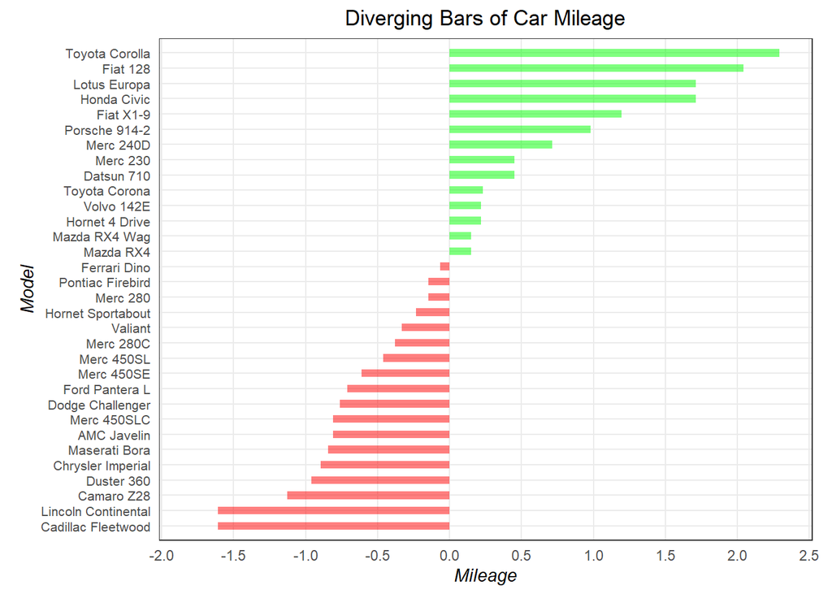

```r
df <- datasets::mtcars %>% data.table() %>% .[,cars:=rownames(mtcars)]
df[, mpg_z := (mpg-mean(mpg))/sd(mpg)]
df[mpg_z > 0, mpg_c := "g"]
df[mpg_z <= 0, mpg_c := "r"]

# 注意Ferrari Dino和原版数值不一样，可能是数据的问题，用本地数据R和Python画出图结果一样
ggplot(df, aes(x = reorder(cars, mpg_z), y = mpg_z, fill = mpg_c))+
  geom_bar(stat = "identity", alpha = 0.5, width = 0.5, show.legend = F)+
  scale_fill_manual(values = c("r" = "red", "g" = "green"))+
  scale_x_discrete(expand = c(0.03, 0.03))+
  scale_y_continuous(limits = c(-2, 2.5), breaks = seq(-2, 2.5, by = 0.5), expand = c(0,0.02))+
  coord_flip()+
  labs(x = "Model", y = "Mileage", title = "Diverging Bars of Car Mileage")+
  theme_bw()+
  theme(aspect.ratio = 1/1.3,
        axis.ticks = element_blank(),
        axis.title = element_text(face = "italic"),
        axis.text.y = element_text(size = 8),
        panel.grid.minor = element_blank(),
        plot.title = element_text(hjust = 0.5))
```

# 11. 条形图（带文字、发散型）

Diverging Texts

发散文本类似于发散条形，如果您想以美观且美观的方式显示图表中每个项目的值，则首选文本。

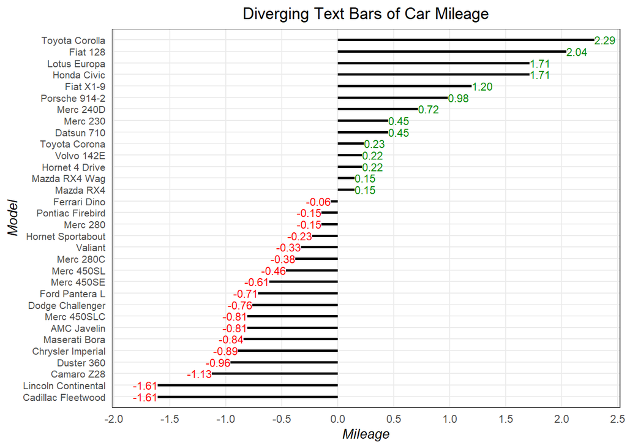

```r
df <- datasets::mtcars %>% data.table() %>% .[,cars:=rownames(mtcars)]
df[, mpg_z := (mpg-mean(mpg))/sd(mpg)]
df[mpg_z > 0, mpg_c := "g"]
df[mpg_z <= 0, mpg_c := "r"]

# 注意Ferrari Dino和原版数值不一样，可能是数据的问题，用本地数据R和Python画出图结果一样
ggplot(df, aes(y = reorder(cars, mpg_z)))+
  geom_linerange(aes(xmin = 0, xmax = mpg_z), linewidth = 1, show.legend = F)+
  geom_text(data = df[mpg_c == "g",], mapping = aes(x = mpg_z, label = sprintf("%.2f",mpg_z)), hjust = 0, color = "green4", size = 3)+
  geom_text(data = df[mpg_c == "r",], mapping = aes(x = mpg_z, label = sprintf("%.2f",mpg_z)), hjust = 1, color = "red", size = 3)+
  scale_x_continuous(limits = c(-2, 2.5), breaks = seq(-2, 2.5, by = 0.5), expand = c(0,0.02))+
  scale_y_discrete(expand = c(0.03, 0.03))+
  labs(x = "Mileage", y = "Model", title = "Diverging Text Bars of Car Mileage")+
  theme_bw()+
  theme(axis.ticks = element_blank(),
        axis.title = element_text(face = "italic"),
        axis.text.y = element_text(size = 8),
        panel.grid.minor = element_blank(),
        plot.title = element_text(hjust = 0.5))
```

# 12. 点图（发散型）

Diverging Dot Plot

分流点图也类似于发散条。然而，与发散条相比，没有条形减少了组之间的对比度和差异量。

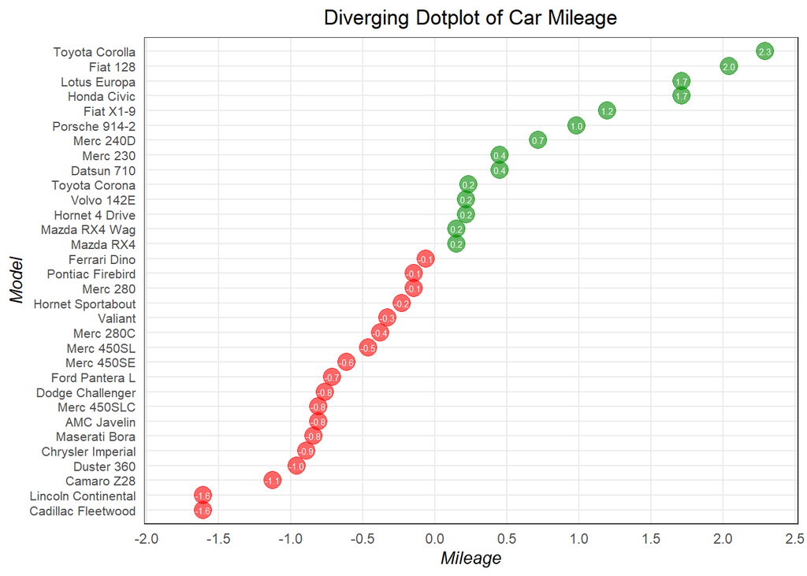

```r
df <- datasets::mtcars %>% data.table() %>% .[,cars:=rownames(mtcars)]
df[, mpg_z := (mpg-mean(mpg))/sd(mpg)]
df[mpg_z > 0, mpg_c := "g"]
df[mpg_z <= 0, mpg_c := "r"]

# 注意Ferrari Dino和原版数值不一样，可能是数据的问题，用本地数据R和Python画出图结果一样
ggplot(df, aes(y = reorder(cars, mpg_z), x = mpg_z, color = mpg_c, label = sprintf("%.1f",mpg_z)))+
  geom_point(size = 5, alpha = 0.6, show.legend = F)+
  geom_text(size = 2, hjust = 0.5, color = "white")+
  scale_x_continuous(limits = c(-2, 2.5), breaks = seq(-2, 2.5, by = 0.5), expand = c(0,0.02))+
  scale_y_discrete(expand = c(0.03, 0.03))+
  scale_color_manual(values = c("r" = "red", "g" = "green4"))+
  labs(x = "Mileage", y = "Model", title = "Diverging Dotplot of Car Mileage")+
  theme_bw()+
  theme(axis.ticks = element_blank(),
        axis.title = element_text(face = "italic"),
        axis.text.y = element_text(size = 8),
        panel.grid.minor = element_blank(),
        plot.title = element_text(hjust = 0.5))
```

# 13. 棒棒糖图（带标记）

Diverging Lollipop Chart with Markers

带标记的棒棒糖提供了一种灵活的方法来可视化偏差，方法是强调想要引起注意的任何重要数据点并在图表中适当地进行推理。

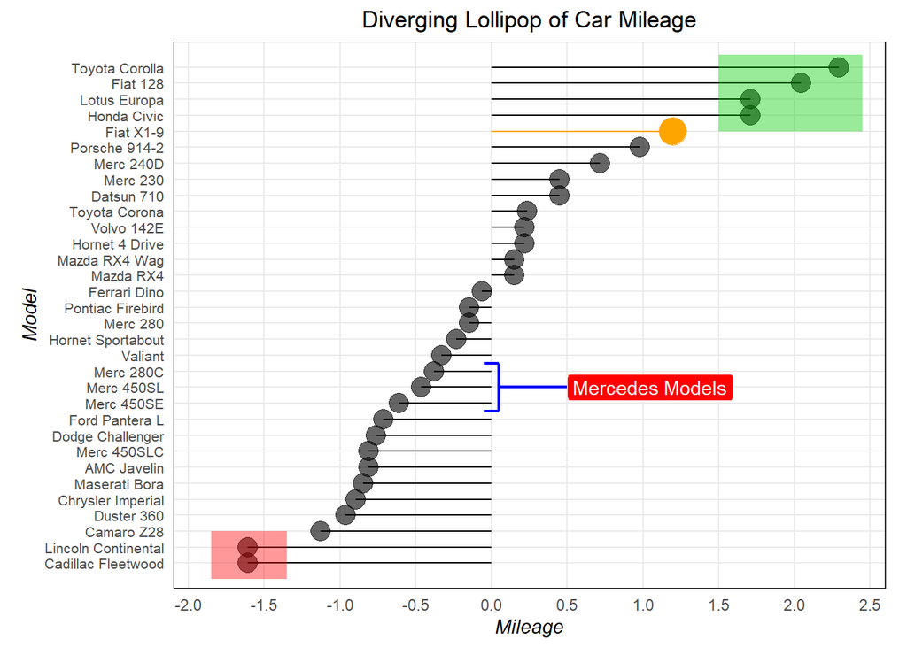

```r
df <- datasets::mtcars %>% data.table() %>% .[,cars:=rownames(mtcars)]
df[, mpg_z := (mpg-mean(mpg))/sd(mpg)]
# 方框标注数据
df_rect <- data.table(x_min = c(1.5, -1.85),
                      x_max = c(2.45, -1.35),
                      y_min = c(28, 0),
                      y_max = c(32.8, 3),
                      rec_group = c("g", "r"))
# 线段括号数据
df_line <- data.table(x_point = c(-0.1, 0, -0.1, 0, 0, 0, 0, 0.5)+0.05,    #原图太难看了，这里整体向右平移0.05
                      y_point = c(10.5, 10.5, 13.5, 13.5, 10.5, 13.5, 12, 12),
                      line_group = c(1,1,2,2,3,3,4,4))

# 注意Ferrari Dino和原版数值不一样，可能是数据的问题，用本地数据R和Python画出图结果一样
# 注意原版，代码和图中的标题也不一样，说明也是复制前面的代码，而且后期改了代码，但没再运行
ggplot(df, aes(y = reorder(cars, mpg_z), x = mpg_z))+
  geom_linerange(aes(xmin = 0, xmax = mpg_z), linewidth = 0.5)+
  geom_point(size = 5, alpha = 0.6)+
  geom_linerange(data = df[cars == "Fiat X1-9",], aes(y = cars, xmin = 0, xmax = mpg_z), linewidth = 0.5, color = "orange")+
  geom_point(data = df[cars == "Fiat X1-9",], aes(y = cars, x = mpg_z), size = 7, alpha = 1, color = "orange")+
  geom_rect(data = df_rect, mapping = aes(x= NULL, y = NULL,
                                          xmin = x_min, xmax = x_max,
                                          ymin = y_min, ymax = y_max, fill = rec_group), alpha = 0.4, show.legend = F)+
  geom_line(data = df_line, mapping = aes(x = x_point, y = y_point, group = line_group), linewidth = 0.8, color = "blue1")+
  geom_label(data = NULL, aes(x = 0.5, y = 12, label = "Mercedes Models"), hjust = 0, fill = "red", color = "white")+
  scale_fill_manual(values = c("g" = "green3", "r" = "red"))+
  scale_x_continuous(limits = c(-2, 2.5), breaks = seq(-2, 2.5, by = 0.5), expand = c(0,0.1))+
  scale_y_discrete(expand = c(0.05, 0.05))+
  labs(x = "Mileage", y = "Model", title = "Diverging Lollipop of Car Mileage")+
  theme_bw()+
  theme(aspect.ratio = 1/1.3,
        axis.ticks = element_blank(),
        axis.title = element_text(face = "italic"),
        axis.text.y = element_text(size = 8),
        panel.grid.minor = element_blank(),
        plot.title = element_text(hjust = 0.5))
```

# 14. 面积图

Area Chart

通过对轴和线之间的区域进行着色，面积图不仅更加强调波峰和波谷，还更加强调高点和低点的持续时间。高点持续时间越长，线下面积越大。

这个图需要注意，如果不填充不同颜色，则没什么问题，一旦要以x轴为分界，上下填充不同颜色，则需要差值以增加数据密度。

```r
#显示英文日期名
Sys.setlocale(category = "LC_TIME", locale = "English")
```

```
## [1] "English_United States.1252"
```

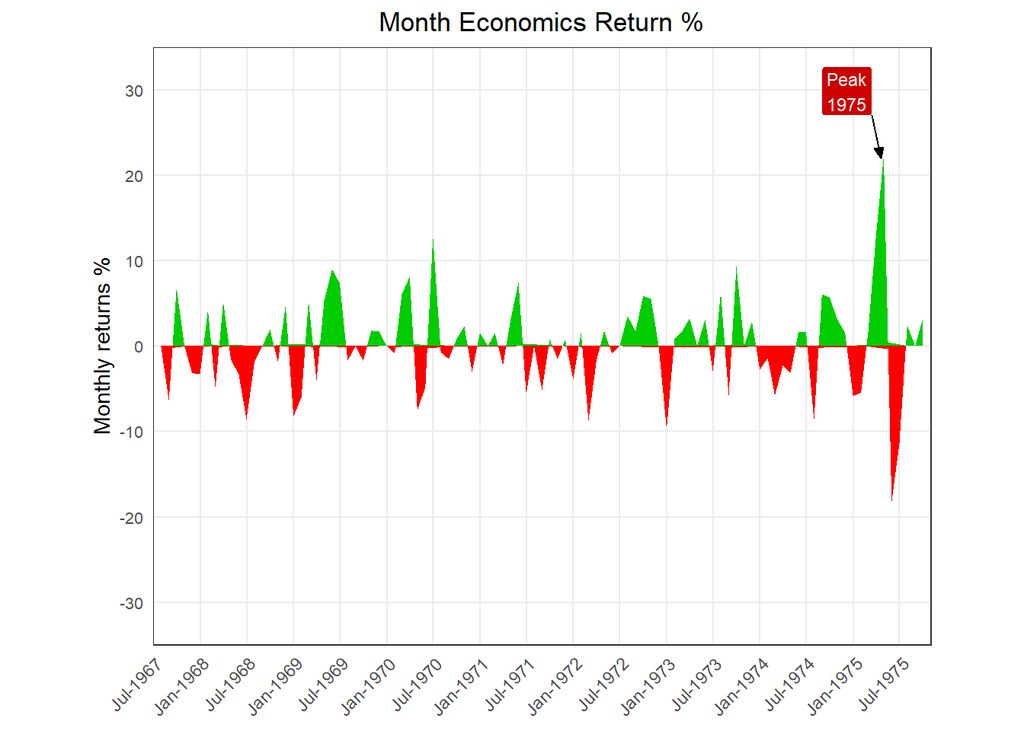

```r
# 准备一个差值函数，用以扩充数据量，
# 目的是，例如对于y正、负、正交替出现的情况，即x1的y>0，之后有部分x2,x3...xn-1的y<0，然后又是xn的y>0，函数将x尽量细分，以使x1和xn的y值接近0,
# 这样对y>0和y<0填充不同颜色时，让x2,x3...xn-1的y>0部分填充足够小以至于看不见（若不对y>0和y<0填充不同颜色，则不会填充这部分）
# 函数处理过后的数据，对y>0和y<0填充不同颜色，与填充相同颜色，填充部分看起来是一样的
dat_interp = function(x, y, line = 0, length.out=500) {
  a <- approx(x, x, xout=seq(min(x), max(x), length.out=length.out))$y
  b <- approx(x, y, xout=seq(min(x), max(x), length.out=length.out))$y
  if("POSIXct" %in% class(x)) a <- as.POSIXct(a, origin='1970-01-01', tz='UTC')
  res <- data.table(x = a, y = b)
  res[y < line, value:="lower"]
  res[y >= line, value:="greater"]
  return(res)
}
# 这个数据与ggplot2::economics数值稍有差异，这里没用R内部数据
# df <- fread("https://github.com/selva86/datasets/raw/master/economics.csv")
df <- fread("data5_economics.csv") %>% .[1:100,]
df[, returns:=c(0,diff(df$psavert)/df$psavert[1:99])*100] #注意这里的计算方法，本期增长率=(本期-上期)/上期
# 差值为新数据
df_date <- df[["date"]] %>% as.POSIXct(tz = "UTC")  #提取日期
df_inte <- dat_interp(df_date, df$returns, length.out = 5000)
# 箭头数据
df_arro <- data.table(x = as.POSIXct(c("1975-03-15", "1975-04-20")), y = c(27, 22))
# 标签数据
df_labe <- data.table(x = as.POSIXct("1975-03-15"), y = 27, l = "Peak\n1975")
b_date <- as.POSIXct("1967-07-01", tz = "UTC")
e_date <- as.POSIXct("1975-11-01", tz = "UTC")

ggplot()+
  geom_area(data = df_inte, aes(x, y, fill = value), show.legend = F)+
  geom_line(data = df_arro, aes(x,y), arrow = arrow(length = unit(0.2, "cm"), type = "closed", angle = 25))+
  geom_label(data = df_labe, aes(x,y,label = l), hjust = 1, vjust = 0, fill = "red3", color = "white", size = 3)+
  scale_fill_manual(values = c("greater" = "green3", "lower" = "red"))+
  scale_x_datetime(date_labels = "%b-%Y", breaks = seq(b_date, e_date, by = "6 month"), limits = c(b_date, e_date), expand = c(0,0))+
  scale_y_continuous(limits = c(-35,35), expand = c(0,0), breaks = seq(-30,30,10))+
  labs(x = NULL, y = "Monthly returns %", title = "Month Economics Return %")+
  theme_bw()+
  theme(aspect.ratio = 1/1.3,
        axis.ticks = element_blank(),
        axis.text.x = element_text(angle = 45, hjust = 1),
        axis.text.y = element_text(size = 8),
        panel.grid.minor = element_blank(),
        plot.title = element_text(hjust = 0.5))
```

# >>> 排序 —————

# 15. 条形图（带排序）

Ordered Bar Chart

有序条形图有效地传达项目的排名顺序。但是，将图表上方的指标值相加，用户将从图表本身获得准确的信息。这是一种基于计数或任何给定指标可视化项目的经典方法。

## 图1，简化版

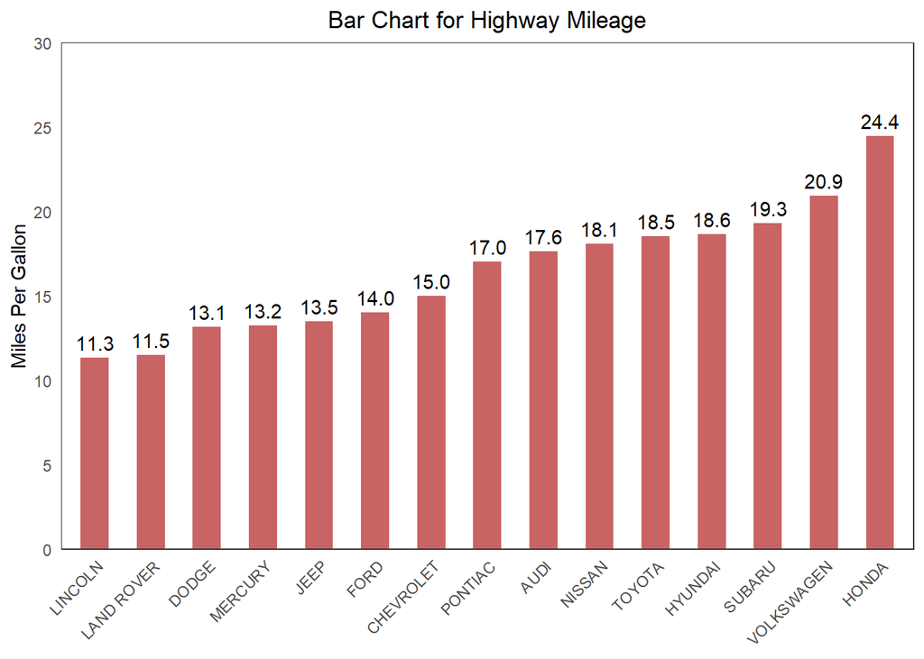

```r
df <- ggplot2::mpg %>%
  data.table() %>%
  .[, lapply(.SD, mean), .SDcols="cty", by = "manufacturer"] %>%
  setorder(cty) %>%
  .[, manufacturer:=toupper(manufacturer)]

# 简化图，除坐标轴底纹外都相同
ggplot(df, aes(reorder(manufacturer, cty), cty))+
  geom_bar(stat = "identity", fill = "#c96464", width = 0.5)+
  geom_text(aes(label = sprintf("%.1f", cty)), vjust = -0.5)+
  scale_y_continuous(limits = c(0, 30), breaks = seq(0, 30, 5), expand = c(0,0))+
  labs(x = NULL, y = "Miles Per Gallon", title = "Bar Chart for Highway Mileage")+
  theme_bw()+
  theme(axis.text.x = element_text(angle = 45, hjust = 1),
        axis.ticks = element_blank(), plot.background = element_rect(fill = NULL),
        panel.grid = element_blank(),
        plot.title = element_text(hjust = 0.5))
```

## 图2，完整版

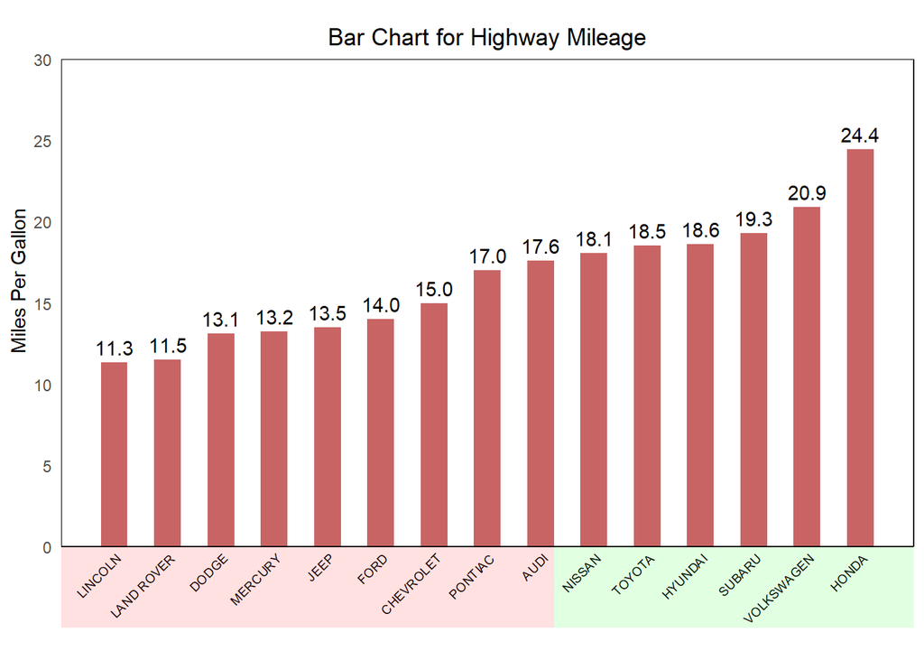

```r
df <- ggplot2::mpg %>%
  data.table() %>%
  .[, lapply(.SD, mean), .SDcols="cty", by = "manufacturer"] %>%
  setorder(cty) %>%
  .[, manufacturer:=toupper(manufacturer)]

# 如果追求一致，可以换一种思路，自己画x和y轴，并添加标签，但是会相当麻烦
ggplot(df, aes(reorder(manufacturer, cty), cty))+
  geom_bar(stat = "identity", fill = "#c96464", width = 0.5)+
  geom_text(aes(label = sprintf("%.1f", cty)), vjust = -0.5)+
  # 自定义border
  geom_hline(yintercept = c(0,30), linewidth = 0.5)+
  geom_linerange(data = NULL, aes(x = -0, ymin = 0, ymax = 30))+
  geom_linerange(data = NULL, aes(x = 16, ymin = 0, ymax = 30))+
  # 自定义x轴标签和填充
  geom_text(aes(y = -0.3, label = manufacturer), vjust = 1, hjust = 1, angle = 45, size = 2.5)+
  geom_rect(data = NULL, aes(xmin = 0, xmax = 9.25, ymin = -5, ymax = 0), fill = "red1", alpha = 0.008)+
  geom_rect(data = NULL, aes(xmin = 9.25, xmax = 16, ymin = -5, ymax = 0), fill = "green3", alpha = 0.008)+
  # 将y轴负值部分留出空白，y轴标签可不自定义，但显示范围仅限于正值
  scale_x_discrete(expand = c(0,0))+
  scale_y_continuous(limits = c(-5, 30), breaks = seq(0, 30, 5), expand = c(0,0))+
  labs(x = NULL, y = "Miles Per Gallon", title = "Bar Chart for Highway Mileage")+
  theme_bw()+
  theme(aspect.ratio = 1/1.5,
        axis.text.x = element_blank(),
        axis.line = element_blank(),
        axis.ticks = element_blank(),
        axis.title.y = element_text(hjust = 0.65), #微调y标题以居中，注意标题方向上的水平，是图的竖直方向
        panel.grid = element_blank(),
        panel.border = element_blank(),
        plot.title = element_text(hjust = 0.5))
```

# 16. 棒棒糖图

Lollipop Chart

棒棒糖图表的作用与有序条形图类似，具有视觉上令人愉悦的方式。

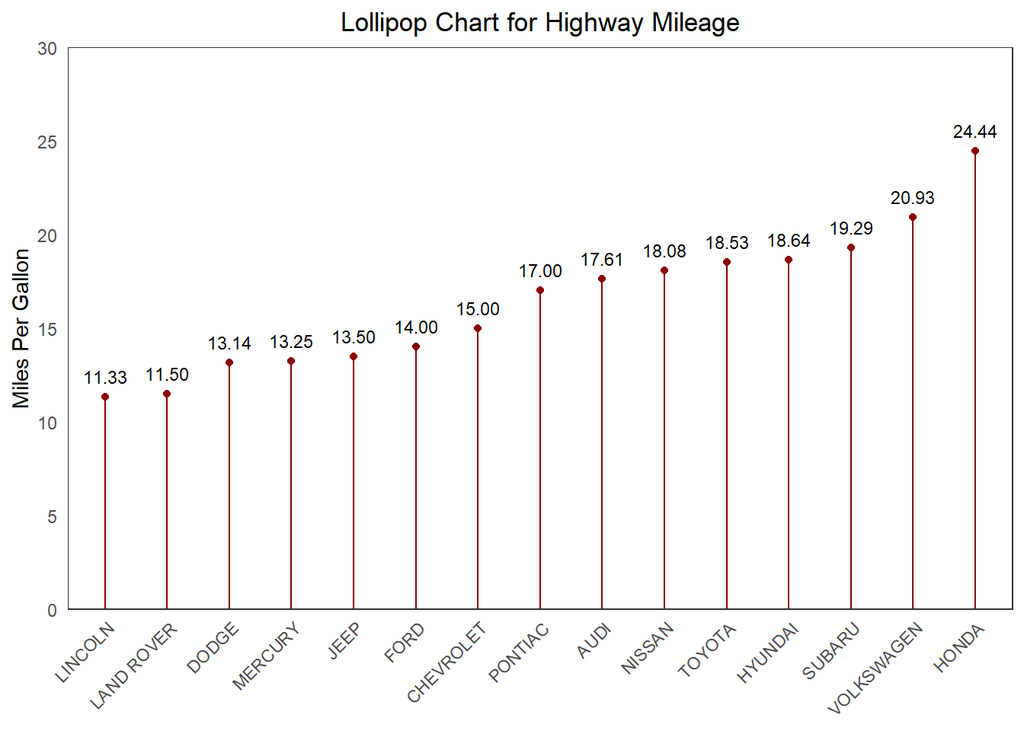

```r
df <- ggplot2::mpg %>%
  data.table() %>%
  .[, lapply(.SD, mean), .SDcols="cty", by = "manufacturer"] %>%
  setorder(cty) %>%
  .[, manufacturer:=toupper(manufacturer)]

ggplot(df, aes(reorder(manufacturer, cty), cty))+
  geom_linerange(aes(ymin = 0, ymax = cty), color = "red4")+
  geom_point(color = "red4")+
  geom_text(aes(label = sprintf("%.2f", cty)), size = 3, vjust = -1)+
  scale_y_continuous(limits = c(0, 30), breaks = seq(0, 30, 5), expand = c(0,0))+
  labs(x = NULL, y = "Miles Per Gallon", title = "Lollipop Chart for Highway Mileage")+
  theme_bw()+
  theme(axis.text.x = element_text(angle = 45, hjust = 1),
        axis.ticks = element_blank(),
        panel.grid = element_blank(),
        plot.title = element_text(hjust = 0.5))
```

# 17. 点图

Dot Plot

点图表示项目的排名顺序。由于它沿水平轴对齐，因此您可以更轻松地可视化点之间的距离。

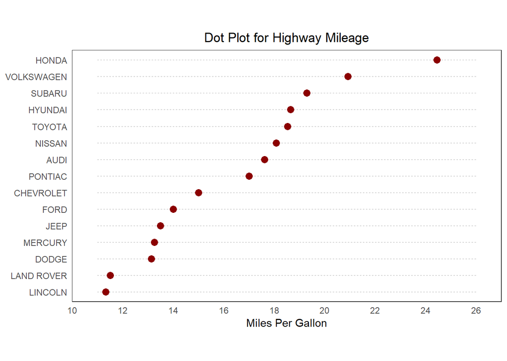

```r
df <- ggplot2::mpg %>%
  data.table() %>%
  .[, lapply(.SD, mean), .SDcols="cty", by = "manufacturer"] %>%
  setorder(cty) %>%
  .[, manufacturer:=toupper(manufacturer)]

ggplot(df, aes(cty, reorder(manufacturer, cty)))+
  geom_linerange(aes(xmin = 11, xmax = 26), linetype = 2, linewidth = 0.25, alpha = 0.3)+
  geom_point(color = "red4", size = 3)+
  scale_x_continuous(limits = c(10, 27), breaks = seq(10, 27, 2), expand = c(0,0))+
  labs(x = "Miles Per Gallon", y = NULL, title = "Dot Plot for Highway Mileage")+
  theme_bw()+
  theme(aspect.ratio = 1/1.7,
        axis.ticks = element_blank(),
        panel.grid = element_blank(),
        plot.title = element_text(hjust = 0.5))
```

# 18. 斜率图

Slope Chart

斜率图最适合比较给定人员/项目的“之前”和“之后”位置。

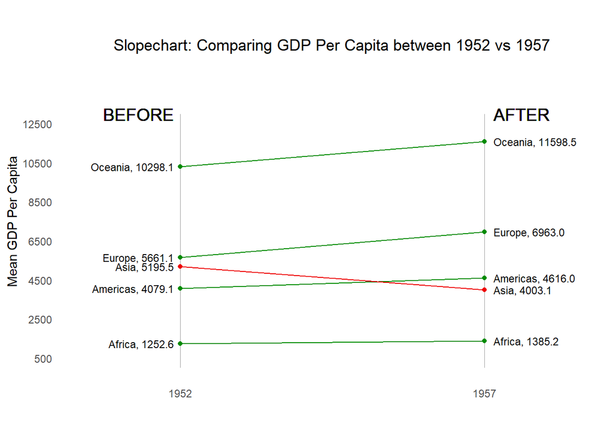

```r
# df <- fread("https://raw.githubusercontent.com/selva86/datasets/master/gdppercap.csv", header = T)
df <- fread("data6_gdppercap.csv", header = T)
df_dat <- df[, trend:=ifelse(df[["1952"]] - df[["1957"]]>0, "down", "up")] %>%
  melt(id.vars = c("continent", "trend"), variable.name = "year", value.name = "gdp")
df_lab_bef <- df_dat[year == "1952", ] %>% .[,l:=sprintf("%s, %.1f", continent, gdp)]
df_lab_aft <- df_dat[year == "1957", ] %>% .[,l:=sprintf("%s, %.1f", continent, gdp)]

# 一个线段上，不同点负值不同颜色，则按这条线段第一个点的颜色画
ggplot(df_dat, aes(year, gdp, color = trend))+
  geom_line(aes(group = continent), show.legend = F)+
  geom_linerange(aes(x = year, ymin = 0, ymax = 13000), color = "gray60", linewidth = 0.2, alpha = 0.5)+
  geom_point(show.legend = F)+
  geom_text(data = df_lab_bef, aes(0.98, gdp, label = l), color = "black", size = 3, hjust = 1)+
  geom_text(data = df_lab_aft, aes(2.03, gdp, label = l), color = "black", size = 3, hjust = 0)+
  geom_text(data = NULL, aes(0.98, 13000, label = "BEFORE"), color = "black", size = 5, hjust = 1)+
  geom_text(data = NULL, aes(2.03, 13000, label = "AFTER"), color = "black", size = 5, hjust = 0)+
  scale_color_manual(values = c("up" = "green4", "down" = "red2"))+
  scale_x_discrete(expand = c(0.2,0.2))+
  scale_y_continuous(limits = c(0, 15000), breaks = seq(500, 12500, 2000))+
  labs(x = NULL, y = "Mean GDP Per Capita", title = "Slopechart: Comparing GDP Per Capita between 1952 vs 1957")+
  theme_bw()+
  theme(aspect.ratio = 1/1.7,
        axis.ticks = element_blank(),
        panel.grid = element_blank(),
        panel.border = element_blank(),
        plot.title = element_text(hjust = 0.5))
```

# 19. 哑铃图

Dumbbell Plot

哑铃图传达了各种物品的“之前”和“之后”位置以及物品的等级顺序。如果您想可视化特定项目/计划对不同对象的影响，它非常有用。

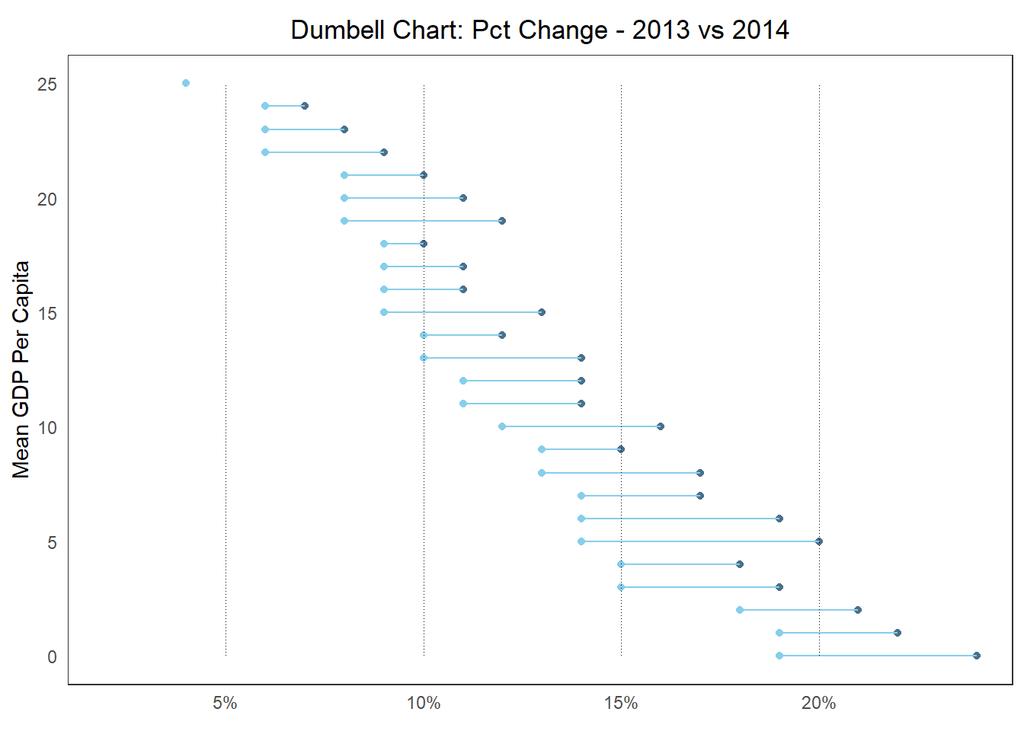

```r
# 数据排序，默认结果R和python不同，这里没有采用默认形式，第一排序指标相同，次要指标按pct_2013再排一次
# df <- fread("https://raw.githubusercontent.com/selva86/datasets/master/health.csv")
df <- fread("data7_health.csv") %>% setorder(pct_2014, pct_2013) %>% .[, index:=(nrow(.)-1):0]
df_line <- data.table(x = c(0.05, 0.10, 0.15, 0.20), ymin = c(0,0,0,0), ymax = c(25,25,25,25))

# 原版里横坐标百分数标错了，这里改过来了
ggplot(df, aes(y = index))+
  geom_point(aes(x = pct_2013), color = "skyblue4")+
  geom_point(aes(x = pct_2014), color = "skyblue")+
  geom_linerange(aes(xmin = pct_2014, xmax = pct_2013), color = "skyblue")+
  geom_linerange(data = df_line, aes(x = x, y = NULL, ymin = ymin, ymax = ymax), linetype = 3, linewidth = 0.1)+
  scale_y_continuous(limits = c(0, 25), breaks = seq(0, 25, 5)) +
  scale_x_continuous(limits = c(0.01, 0.249), breaks = seq(0, 0.25, 0.05), labels = scales::percent, expand = c(0,0))+
  labs(x = NULL, y = "Mean GDP Per Capita", title = "Dumbell Chart: Pct Change - 2013 vs 2014")+
  theme_bw()+
  theme(aspect.ratio = 1/1.5,
        axis.ticks = element_blank(),
        panel.grid = element_blank(),
        plot.title = element_text(hjust = 0.5))
```

# >>> 分布 —————

# 20. 直方图

Histogram for Continuous Variable

直方图显示给定变量的频率分布。下面的表示基于分类变量对频率条进行分组，从而更深入地了解连续变量和分类变量。

## 图1，原版

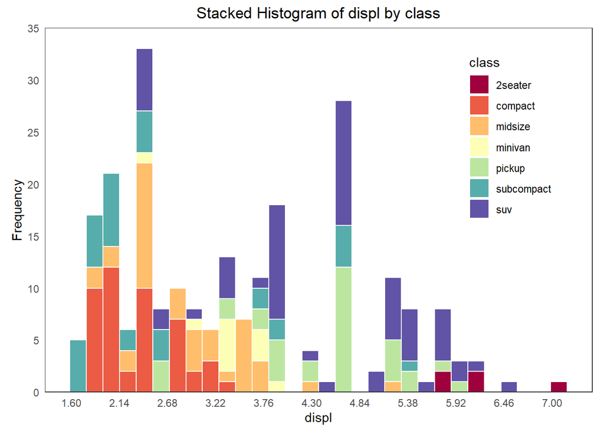

```r
fill_color <- c("#9e013d", "#ec5b43", "#ffbe6c","#fdffb6", "#bce69f", "#57adab", "#6153a6")
x_b <- c(1.6 , 2.14, 2.68, 3.22, 3.76, 4.3 , 4.84, 5.38, 5.92, 6.46, 7.0 )

# 注意，这个划分的结果和python的不同，我也不知道，如何完全复刻python的划分方式
ggplot(ggplot2::mpg, aes(displ, fill = class))+
  geom_histogram(color = "white", bins = 30, position = position_stack(reverse = T), closed = "right")+
  scale_fill_manual(values = fill_color)+
  scale_x_continuous(breaks = x_b)+
  scale_y_continuous(limits = c(0, 35), breaks = seq(0, 35, 5), expand = c(0,0))+
  labs(x = "displ", y = "Frequency", title = "Stacked Histogram of displ by class")+
  theme_bw()+
  theme(aspect.ratio = 1/1.5,
        axis.ticks = element_blank(),
        panel.grid = element_blank(),
        legend.position = c(0.85, 0.7),
        plot.title = element_text(hjust = 0.5))
```

## 图2，修改版

python这个图我认为画的实在不好，下面我用R另画了一个，清楚的展示了每个bar的宽度和大小，若要对照具体数据查看，使用这个代码`setDT(mpg);dcast(mpg[,c("displ","class")], class~displ)`

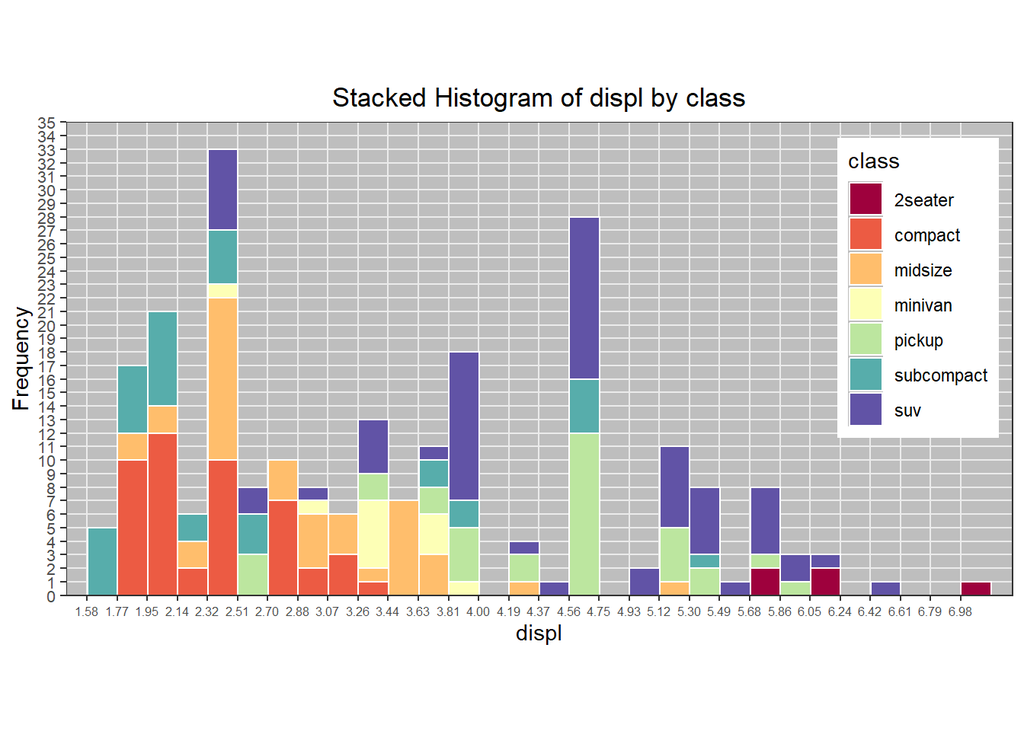

```r
fill_color <- c("#9e013d", "#ec5b43", "#ffbe6c","#fdffb6", "#bce69f", "#57adab", "#6153a6")
x_b <- c(1.6 , 2.14, 2.68, 3.22, 3.76, 4.3 , 4.84, 5.38, 5.92, 6.46, 7.0 )-0.02 #-0.02让截断正好在bar的两端，这个0.02是试出来的
x_bin_w <- seq(x_b[1], x_b[length(x_b)], length.out = 30)  #最后一个直方块是在最后一个截断右边，因此长度还是30

# 注意，这个划分的结果和python的不同，我也不知道，如何完全复刻python的划分方式
# 注意，当x轴的limits比数据宽（至少多宽出一个bar的宽度），则会由提示出现移除了缺失值，实际上并没有对影响数据
ggplot(ggplot2::mpg, aes(displ, fill = class))+
  geom_histogram(color = "white", bins = 30, position = position_stack(reverse = T), closed = "right")+
  scale_fill_manual(values = fill_color)+
  scale_x_continuous(breaks = x_bin_w, labels = function(x) sprintf("%.2f", x), expand = c(0.02,0.02))+
  scale_y_continuous(limits = c(0, 35), breaks = seq(0, 35, 1), expand = c(0,0))+
  labs(x = "displ", y = "Frequency", title = "Stacked Histogram of displ by class")+
  theme_bw()+
  theme(aspect.ratio = 1/2,
        axis.text.x = element_text(size = 6),
        axis.text.y = element_text(size = 8),
        panel.grid.minor = element_blank(),
        panel.background = element_rect(fill = "gray"),
        legend.position = c(0.9, 0.65),
        plot.title = element_text(hjust = 0.5))
```

# 21. 直方图（带分类）

分类变量的直方图显示该变量的频率分布。通过为条形着色，您可以可视化与表示颜色的另一个分类变量相关的分布。

Histogram for Categorical Variable

不用看了，python这个图有极大的问题： 1. 离散数据不能画直方图，只能画条形图 2. 用这两条代码，可以看出教程中的图（用Python再画出来的还是正确的）和数据根本不对应：`df[manufacturer == "lincoln"];df[manufacturer == "mercury"]`

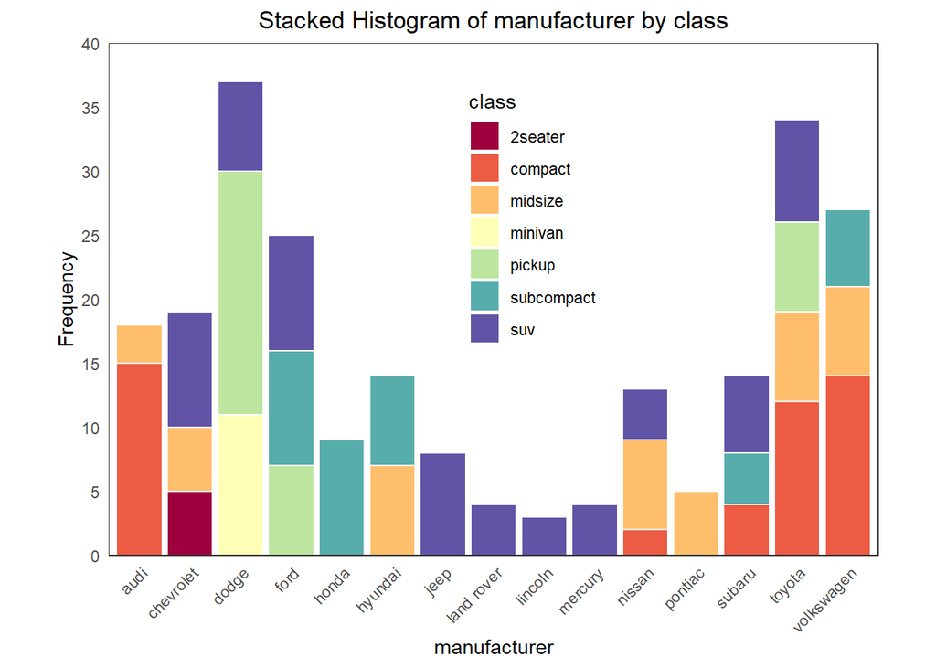

```r
fill_color <- c("#9e013d", "#ec5b43", "#ffbe6c","#fdffb6", "#bce69f", "#57adab", "#6153a6")
df <- ggplot2::mpg %>% data.table() %>% .[,manufacturer:=factor(manufacturer, levels = sort(unique(mpg$manufacturer)))]

ggplot(df, aes(manufacturer, fill = class))+
  geom_bar(color = "white", position = position_stack(reverse = T))+
  scale_fill_manual(values = fill_color)+
  scale_y_continuous(limits = c(0, 40), breaks = seq(0, 40, 5), expand = c(0,0))+
  labs(x = "manufacturer", y = "Frequency", title = "Stacked Histogram of manufacturer by class")+
  theme_bw()+
  theme(aspect.ratio = 1/1.5,
        axis.ticks = element_blank(),
        axis.text.x = element_text(angle = 45, vjust = 1, hjust = 1),
        panel.grid = element_blank(),
        legend.position = c(0.55, 0.66),
        plot.title = element_text(hjust = 0.5))
```

# 22. 密度图

Density Plot

密度图是可视化连续变量分布的常用工具。通过按“响应”变量对它们进行分组，可检查X和Y之间的关系。下图描述里程的分布如何随气缸数量而变化。

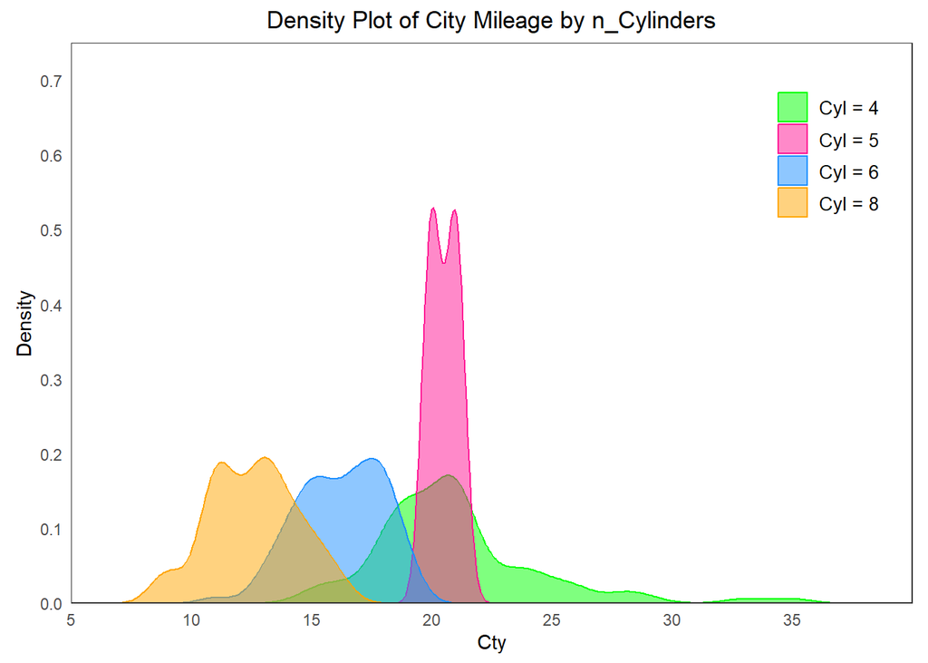

```r
d_color <- c("green", "deeppink", "dodgerblue", "orange")
df <- ggplot2::mpg %>% data.table() %>% .[, cyl:=factor(cyl, levels = sort(unique(mpg$cyl)))]

ggplot(df, aes(cty, group = cyl, fill = cyl, color = cyl))+
  geom_density(alpha = 0.5)+
  scale_fill_manual(values = d_color, labels = paste0("Cyl = ", levels(df$cyl)))+
  scale_color_manual(values = d_color, labels = paste0("Cyl = ", levels(df$cyl)))+
  scale_x_continuous(limits = c(5, 40), breaks = seq(5, 35, 5), expand = c(0,0))+
  scale_y_continuous(limits = c(0, 0.75), breaks = seq(0, 0.7, 0.1), expand = c(0,0))+
  guides(fill = guide_legend(title = NULL), color = guide_legend(title = NULL))+
  labs(x = "Cty", y = "Density", title = "Density Plot of City Mileage by n_Cylinders")+
  theme_bw()+
  theme(aspect.ratio = 1/1.5,
        axis.ticks = element_blank(),
        panel.grid = element_blank(),
        legend.text = element_text(size = 10),
        legend.position = c(0.9, 0.8),
        plot.title = element_text(hjust = 0.5))
```

# 23. 密度图（带直方）

Density Curves with Histogram

带有直方图的密度曲线将两个图传达的集体信息汇集在一起。

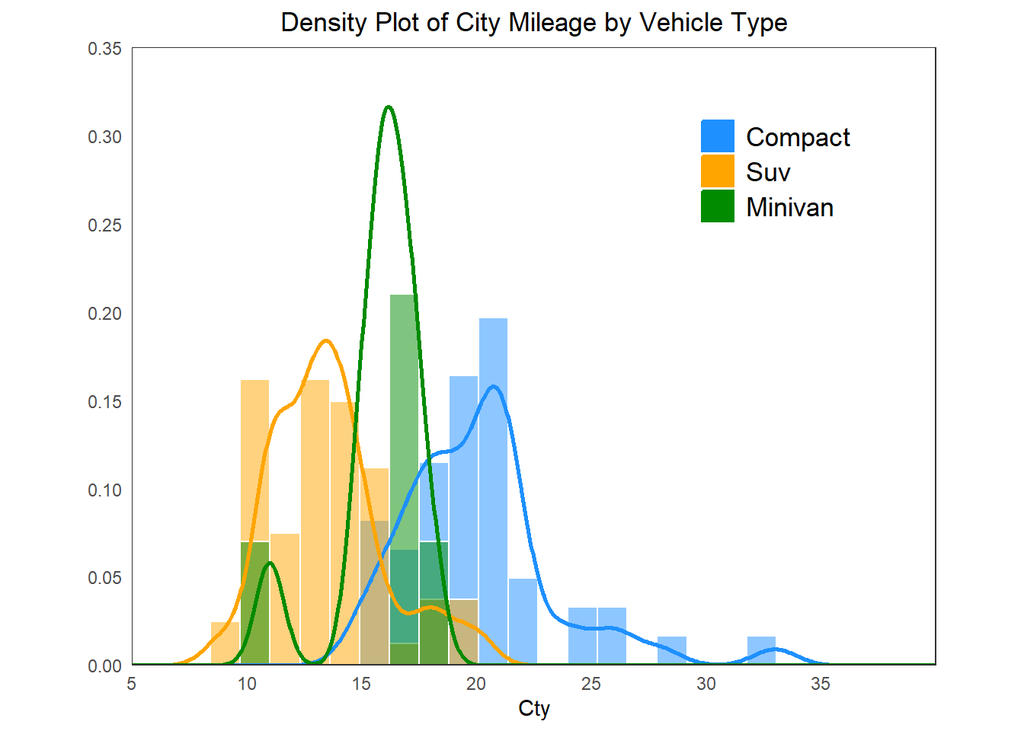

```r
library(stringr)
c_color <- c("dodgerblue", "orange", "green4")
s_class <- c("compact", "suv", "minivan")
df <- ggplot2::mpg %>% data.table() %>% .[class %in% s_class, ] %>% .[,class:=factor(class, levels = s_class)]

# 这个图与python不同的是，所有的geom_histogram以同样的x轴标度进行划分，因此前后柱子是完全重叠的
ggplot()+
  geom_histogram(data = df, aes(cty, y = after_stat(density), fill = class), color = "white", bins = 28, position = position_identity(), alpha = 0.5)+
  geom_density(data = df, aes(x = cty, group = class, color = class), linewidth = 1)+
  scale_color_manual(values = c_color, labels = str_to_title(s_class))+
  scale_fill_manual(values = c_color, labels =str_to_title(s_class))+
  scale_x_continuous(limits = c(5, 40), breaks = seq(5, 35, 5), expand = c(0,0))+
  scale_y_continuous(limits = c(0, 0.35), breaks = seq(0, 0.35, 0.05), expand = c(0,0))+
  guides(fill = guide_legend(title = NULL), color = guide_legend(title = NULL))+
  labs(x = "Cty", y = NULL, title = "Density Plot of City Mileage by Vehicle Type")+
  theme_bw()+
  theme(aspect.ratio = 1/1.3,
        axis.ticks = element_blank(),
        panel.grid = element_blank(),
        legend.text = element_text(size = 13),
        legend.position = c(0.8, 0.8),
        plot.title = element_text(hjust = 0.5))
```

# 24. 嵴线图

Joy Plot（山脊图/嵴线图/峰峦图）

嵴线图允许不同组的密度曲线重叠，这是可视化大量组彼此之间分布的好方法。它看起来赏心悦目，并清楚地传达了正确的信息。

这个图也与python的有所差别，添加了标签，自定义了核密度估计的带宽。python的带宽我有点不明白，上面的带宽貌似很小，下面的又好像很大。

[figure not shown]

```r
library(ggridges)
library(stringr)
c_color <- c("dodgerblue", "orange")
d_class <- ggplot2::mpg$class %>% unique() %>% sort(decreasing = T)
df <- mpg %>% data.table() %>%
  .[,c("hwy", "cty", "class")] %>%
  .[,class:=factor(class, levels = d_class)] %>%
  melt(id.vars = "class")

# geom_density_ridge函数，没有2是开放图，有2的是密度线和坐标轴都有实线，相当于围起来了
ggplot(df, aes(x = value, y = class, fill = variable))+
  geom_density_ridges2(aes(scale = 3), bandwidth = 0.5)+  #aes中scale是纵向图的长度，bandwidt是核密度的带宽
  scale_fill_manual(values = c_color, labels =str_to_title(s_class))+
  scale_x_continuous(limits = c(5, 50), breaks = seq(10, 50, 10), expand = c(0,0))+
  scale_y_discrete(expand = c(0, 0, 0.4, 0))+  #expand四个元素的向量，分别为下，下，上，上
  guides(fill = guide_legend(title = NULL))+
  labs(x = NULL, y = NULL, title = "Joy Plot of City and Highway Mileage by Class")+
  theme_bw()+
  theme(aspect.ratio = 1/1.3,
        axis.ticks = element_blank(),
        legend.text = element_text(size = 13),
        legend.position = c(0.85, 0.88),
        panel.grid = element_blank(),
        panel.border = element_blank(),
        plot.title = element_text(hjust = 0.5))
```

# 25. 点图（带分布）

Distributed Dot Plot

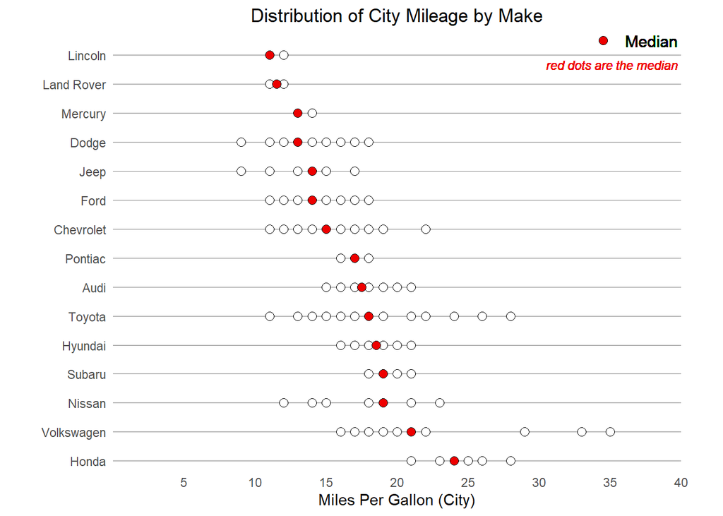

```r
library(stringr)
df <- ggplot2::mpg %>% data.table() %>% .[,c("manufacturer", "cty")]
df_median <- df[, lapply(.SD, median), .SDcols = "cty", by = "manufacturer"] %>% setorder(-cty)
manu_order <- df_median[["manufacturer"]] %>% factor(., levels = .)
df[, manufacturer:=factor(manufacturer, levels = manu_order)]
df_median[, manufacturer:=factor(manufacturer, levels = manu_order)]

ggplot(df, aes(x = cty, y = manufacturer))+
  geom_linerange(data = df_median, aes(x = NULL, xmin = 0, xmax = 40), linewidth = 0.1, color = "gray50")+
  geom_point(shape = 21, size = 3, fill = "white", stroke = 0.05)+
  geom_point(data = df_median, aes(cty, manufacturer), shape = 21, size = 3, fill = "red2", stroke = 0.05)+
  geom_point(data = NULL, aes(34.5, 15.5), shape = 21, size = 3, fill = "red2", stroke = 0.05)+
  geom_text(data = NULL, aes(39.8, 15.5), label = "Median", size = 4, hjust = 1)+
  geom_text(data = NULL, aes(39.8, 14.5), label = "red dots are the median", color = "red2", size = 3, fontface  = "italic", hjust = 1, vjust = 0)+

  scale_x_continuous(limits = c(0, 40), breaks = seq(5, 40, 5), expand = c(0,0))+
  scale_y_discrete(expand = c(0.02, 0.02, 0.05, 0.05), labels = str_to_title(manu_order))+
  labs(x = "Miles Per Gallon (City)", y = NULL, title = "Distribution of City Mileage by Make")+
  theme_bw()+
  theme(aspect.ratio = 1/1.3,
        axis.ticks = element_blank(),
        legend.text = element_text(size = 13),
        legend.position = c(0.6, 0.7),
        panel.grid = element_blank(),
        panel.border = element_blank(),
        plot.title = element_text(hjust = 0.5))
```